# Fig_TimelineGraph

Pauliina Vuorinen

26/09/2022-20/12/2023

# Introduction

The purpose of this script is to create graphs that show the contents of participants’ reading sessions. A timeline plot is created which shows different engagement and reading speed types across time.

## Setup

```r
library(tidyverse)
library(dplyr)
library(timelineS)
```

```r
if (exists("ExternalAnalysisFilePath")) {
    # ExternalAnalysisFilePath: ~/Short_Story_Reading_Behaviour_Public/
    mypath_SSRB <- ExternalAnalysisFilePath
} else if (grepl("Fig", getwd())) {
    mypath_SSRB <- dirname(getwd())
} else if (grepl("Short_Story_Reading_Behaviour_Public", getwd())) {
    mypath_SSRB <- getwd()
} else {
    # get working directory manually
    mypath_SSRB <- paste0(
            dirname(getwd()),
            "/Short_Story_Reading_Behaviour_Public"
        )
}
```

## Load data

To create the timelines we use wrangled_tracking_data which was created in Prep_TrackingDataWrangling.Rmd.

```r
wrangled_tracking_data <-
    read.csv(
        paste0(
            mypath_SSRB,
            "/Data/wrangled_tracking_data.csv"
        ),
        header = TRUE,
        sep = ";",
        dec = ","
    )
wrangled_tracking_data <- select(wrangled_tracking_data, -X)
```

```r
str(wrangled_tracking_data)
```

```
## 'data.frame':    8774 obs. of  78 variables:
##  $ X.1                            : int  1 2 3 4 5 6 7 8 9 10 ...
##  $ StoryId                        : int  1 1 1 1 1 1 1 1 1 1 ...
##  $ UserId                         : int  65 40 65 65 40 65 65 40 40 40 ...
##  $ ReadingSessionNumber           : int  3 1 3 3 1 3 3 1 1 1 ...
##  $ EngagementTypeId               : int  4 17 4 4 17 4 4 17 17 2 ...
##  $ Id                             : int  10228 4821 10227 10225 4822 10229 10226 4824 4820 4729 ...
##  $ NavigationBlockNumber          : int  103 61 103 102 61 103 102 61 61 4 ...
##  $ BaselineSpeed                  : num  62.3 66.1 62.3 62.3 66.1 ...
##  $ IsBaselineSpeedAdjusted        : logi  TRUE TRUE TRUE TRUE TRUE TRUE ...
##  $ AdjustedBaselineSpeed          : num  257 157 257 257 157 ...
##  $ IsIntrinsicCondition           : logi  FALSE TRUE FALSE FALSE TRUE FALSE ...
##  $ Date                           : chr  "2020-06-07" "2020-05-11" "2020-06-07" "2020-06-07" ...
##  $ Time                           : chr  "2022-09-29 00:16:45.195" "2022-09-29 13:33:41.999" "2022-09-29 00:16:44.490" "2022-09-29 00:16:43.649" ...
##  $ TimeBeforeDeadlinesDays        : num  -1.15 13.92 -1.15 -1.15 13.92 ...
```

[output cut: 64 more lines]

```r
source(
    paste0(
        mypath_SSRB,
        "/Functions/Functions_VariableTypeConversion.R"
    )
)

## turn columns into factors that should be factors
wrangled_tracking_data[, c(
    "UserId",
    "StoryId",
    "Direction",
    "NavigationBlockDirection"
)] <- convert.magic(
    wrangled_tracking_data[, c(
        "UserId",
        "StoryId",
        "Direction",
        "NavigationBlockDirection"
    )],
    "factor"
)
## fix numeric columns that were automatically categorised as character
wrangled_tracking_data[, c(
    "BaselineSpeed",
    "DurationMinutes",
    "ReadingBlockDuration",
    "EngagedReadingDuration",
    "EngagedReadingSpeed",
    "NavigationBlockDuration"
)] <- convert.magic(
    wrangled_tracking_data[, c(
        "BaselineSpeed",
        "DurationMinutes",
        "ReadingBlockDuration",
        "EngagedReadingDuration",
        "EngagedReadingSpeed",
        "NavigationBlockDuration"
    )],
    "numeric"
)
## turn reading block (page view) number,
### reading session number, and
#### navigation block number into ordered factors
wrangled_tracking_data[, c(
    "ReadingBlockNumber",
    "ReadingSessionNumber",
    "NavigationBlockNumber"
)] <- convert.magic(
    wrangled_tracking_data[, c(
        "ReadingBlockNumber",
        "ReadingSessionNumber",
        "NavigationBlockNumber"
    )],
    "ordered"
)
## fix logical variables
wrangled_tracking_data[, c(
    "IsBlurred",
    "IsDialogOpen",
    "IsMenuOpen",
    "IsInactive",
    "IsReading",
    "IsPageOpen",
    "IsDurationFixed"
)] <- convert.magic(
    wrangled_tracking_data[, c(
        "IsBlurred",
        "IsDialogOpen",
        "IsMenuOpen",
        "IsInactive",
        "IsReading",
        "IsPageOpen",
        "IsDurationFixed"
    )],
    "logical"
)

## fix date and time variable types
wrangled_tracking_data$Date <-
    as.Date(
        wrangled_tracking_data$Date,
        format = "%Y-%m-%d"
    )
TempTimeObject <- strsplit(wrangled_tracking_data$Time, " ")
TempTimeObject <- sapply(TempTimeObject, '[[', 2)
wrangled_tracking_data$TempTimeObject <- TempTimeObject
wrangled_tracking_data <- dplyr::select(wrangled_tracking_data, -Time)
names(wrangled_tracking_data)[which(colnames(wrangled_tracking_data) == "TempTimeObject")] <- "Time"
op <-
    options(digits.secs = 3)
wrangled_tracking_data$Time <-
    strptime(
        wrangled_tracking_data$Time,
        format = "%H:%M:%OS"
    )
```

```r
# order by User, date, time and event id
wrangled_tracking_data <-
    wrangled_tracking_data[
        with(
            wrangled_tracking_data,
            order(UserId, Date, Time, Id)
        ),
    ]
```

## Create new variables

First, we create a variable that is used as the colours in the timelines. We want to study the contents of reading sessions, and so the colours will show different Engagement types (Engagement/Disengagement/Dialog), in addition to EngagedSpeedLabels_DR (grouped into Slower than Deep Reading/Deep Reading/Faster than deep reading). See more information about engagement types and speed labels in Info folder.

```r
wrangled_tracking_data$EngagedSpeedLabel <- as.character(
    wrangled_tracking_data$EngagedSpeedLabel
)
wrangled_tracking_data$EngagedSpeedLabel_DR <- ifelse(
    wrangled_tracking_data$EngagedSpeedLabel == "SlowReading",
    "SlowerThanDeepReading",
    ifelse(
        wrangled_tracking_data$EngagedSpeedLabel == "Skimming" |
        wrangled_tracking_data$EngagedSpeedLabel == "Scanning" |
        wrangled_tracking_data$EngagedSpeedLabel == "Browsing",
        "FasterThanDeepReading",
        wrangled_tracking_data$EngagedSpeedLabel
    )
)
# create 'TimelineEngagementType' used for colours in the plot
## use speed labels for any engaged reading events, and
### engagement types for disengagements and dialog events
wrangled_tracking_data$TimelineEngagementType <- ifelse(
    wrangled_tracking_data$Engagement == "Engagement",
    wrangled_tracking_data$EngagedSpeedLabel_DR,
    wrangled_tracking_data$Engagement
)
# turn into a factor and fix levels
wrangled_tracking_data$TimelineEngagementType <- as.factor(
    wrangled_tracking_data$TimelineEngagementType
)
wrangled_tracking_data$TimelineEngagementType <- factor(
    wrangled_tracking_data$TimelineEngagementType,
    levels = c(
        "SlowerThanDeepReading",
        "DeepReading",
        "FasterThanDeepReading",
        "Disengagement",
        "Dialog",
        "DisruptedEngagement"
    )
)
```

To calculate the timeline start and end times, we first create some tests:

```r
wrangled_tracking_data$IsNewUser <- (
    wrangled_tracking_data$UserId
    != lag(wrangled_tracking_data$UserId, 1)
)
wrangled_tracking_data$IsNewReadingSession <- (
    wrangled_tracking_data$ReadingSessionNumber
    != lag(wrangled_tracking_data$ReadingSessionNumber, 1)
)
# change 1st values to TRUE
wrangled_tracking_data$IsNewReadingSession[is.na(wrangled_tracking_data$IsNewReadingSession)] <- TRUE
wrangled_tracking_data$IsNewUser[is.na(wrangled_tracking_data$IsNewUser)] <- TRUE

wrangled_tracking_data$IsLastEventInAReadingSession <- (
    lead(wrangled_tracking_data$IsNewUser, 1) |
    lead(wrangled_tracking_data$IsNewReadingSession, 1)
)
# change last value to TRUE
wrangled_tracking_data$IsNewReadingSession[is.na(wrangled_tracking_data$IsLastEventInAReadingSession)] <- TRUE
```

We then create timeline event durations. CumulativeRSTime is used in the timelines as events’ start and end times. Whereas the start time is the previous events’ cumulative reading session duration (CumulativeRSTime), the end time is the current event’s CumulativeRSTime. Each event’s cumulative time includes that event’s duration, and thus a CumulativeRSTime reflects the end of the current event and the beginning of the next event in the same reading session.

Exceptions are done for the first and last event in a reading session:

- The event that begins a new reading session is given a start time of 0
- The event that ends the reading session is given CumulativeRSTime, if the event type is Engagement (Engagement == Engagement). However, if the last event is a disengagement or a dialog event, the event’s end time is set to equal the start time. This is because disengagements and dialog events (events such as ‘close’ or ‘openMenu’) often appear at the end of a reading session, and they indicate that the participant is leaving the e-reader.

```r
# Start time is previous event's cumulative time
## if the current event is not a new user or reading session
### else, set to 0
wrangled_tracking_data$TimelineStartTime <- ifelse(
    !wrangled_tracking_data$IsNewUser &
        !wrangled_tracking_data$IsNewReadingSession,
        lag(wrangled_tracking_data$CumulativeRSTime, 1),
        0
)
# End time == Start time if
## the event is the last event and Engagement != Engagement
### else, End time == CumulativeRSTime
wrangled_tracking_data$TimelineEndTime <- ifelse(
    wrangled_tracking_data$IsLastEventInAReadingSession &
    (wrangled_tracking_data$Engagement != "Engagement"),
    wrangled_tracking_data$TimelineStartTime,
    wrangled_tracking_data$CumulativeRSTime
)
```

## Create timelines

Select five random participants:

```r
set.seed(122)
sample <- sample(
    unique(wrangled_tracking_data$UserId),
    5
)
sample_wrangled_tracking_data <- filter(
    wrangled_tracking_data,
    UserId == sample[1] |
    UserId == sample[2] |
    UserId == sample[3] |
    UserId == sample[4] |
    UserId == sample[5]
)
```

Create a plot without artefacts

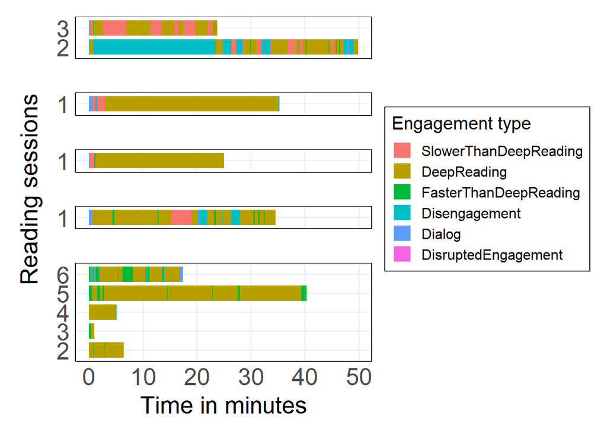

```r
# modify UserId for labelling
sample_wrangled_tracking_data$UserId_Labelled <- dplyr::recode(
    sample_wrangled_tracking_data$UserId,
    "14" = paste0("User", " ", "14"),
    "49" = paste0("User", " ", "49"),
    "53" = paste0("User", " ", "53"),
    "58" = paste0("User", " ", "58"),
    "60" = paste0("User", " ", "60")
)

# create one plot
invisible(
    TimelinePlotPartOne <- timelineG(
        sample_wrangled_tracking_data,
          start = "TimelineStartTime",
          end = "TimelineEndTime",
          names = "ReadingSessionNumber",
          phase = "TimelineEngagementType",
          width = 6,
          group1 = "UserId_Labelled",
          group2 = NA,
        theme = theme_bw() +
            theme(
            plot.margin = margin(0.5, 0.5, 0.5, 0.5, "cm"),
            panel.grid.minor = element_blank(),
            panel.background = element_blank(),
            axis.line = element_line(colour = "black"),
            axis.text.x = element_text(size = 20),
            axis.text.y = element_text(size = 20),
            axis.ticks = element_blank(),
            axis.title.x = element_text(size = 20, vjust = 0.5),
            axis.title.y = element_text(
                size = 20,
                angle = 90,
                vjust = 0.5,
                margin = unit(c(0, 0.5, 0, 0), "cm")),
            plot.title = element_text(size = 20),
            legend.text = element_text(size = 12),
            legend.title = element_text(size = 15),
            legend.key = element_blank(),
          #  legend.position = "top",
           # legend.direction = "vertical",
            strip.background = element_blank(),
            strip.text = element_blank(),
            strip.placement = "top",
            panel.spacing = unit(1, "cm"),
            panel.border = element_rect(colour = "black", fill = NA),
            legend.background = element_rect(color="black", size=.5, linetype="solid")),
        other = labs(
            x = "Time in minutes",
            y = "Reading sessions",
            colour = "Engagement type"))
)
```

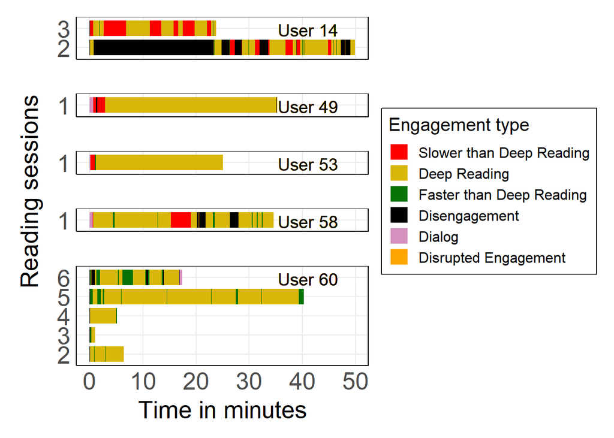

```r
TimelinePlotPartTwo <- TimelinePlotPartOne +
    scale_color_manual(
        values = (
            colours = c(
                "SlowerThanDeepReading" = "red",
                "DeepReading" = "#D8B70A",
                "FasterThanDeepReading" = "#077307",
                "Disengagement" = "black",
                "Dialog" = "#d590be",
                "DisruptedEngagement" = "orange")),
        labels = c(
            "Slower than Deep Reading",
            "Deep Reading",
            "Faster than Deep Reading",
            "Disengagement",
            "Dialog",
            "Disrupted Engagement"
        )) +
        geom_text(aes(label = UserId_Labelled), x = Inf, y = Inf, hjust = 1.5, vjust = 1.5, size = 5)
TimelinePlotPartTwo
```

```r
# ggsave("Fig_TimelinePlot_Sample.png", plot = TimelinePlotPartTwo, dpi = 300, height = 20, width = 25, units = "cm")
```

```r
# create multiple plots in a pdf
i = 1
#plot_list = list()
pdf("Fig_UserTimelines.pdf") # this also includes the basic coloured timelines - had to manually edit for now
for (user in levels(wrangled_tracking_data$UserId)) {
  UserSubset <- filter(wrangled_tracking_data, UserId == user)

    TLPlot <- timelineG(
    UserSubset,
    start = "TimelineStartTime",
    end = "TimelineEndTime",
    names = "ReadingSessionNumber",
    phase = "TimelineEngagementType",
    width = 5,
    group1 = "UserId",
    group2 = NA,
    theme = theme(
      legend.position = "left",
      panel.grid.major = element_blank(),
      panel.grid.minor = element_blank(),
      panel.background = element_blank(),
      axis.line = element_line(colour = "black")
    ),
    #text = element_text(
    #size = 14, family = "Microsoft Sans Serif")),
    other = labs(x = "Time in minutes",
                 y = "Reading session",
                 colour = "Engagement type",
                 caption = user) +

  ) +
    scale_color_manual(
        values = (
            colours = c(
                "SlowerThanDeepReading" = "red",
                "DeepReading" = "#D8B70A",
                "FasterThanDeepReading" = "#077307",
                "Disengagement" = "black",
                "Dialog" = "#d590be",
                "DisruptedEngagement" = "orange")),
        labels = c(
            "Slower than Deep Reading",
            "Deep Reading",
            "Faster than Deep Reading",
            "Disengagement",
            "Dialog",
            "Disrupted Engagement"
        )) +
        geom_vline(xintercept =
            (wrangled_tracking_data[wrangled_tracking_data$IsNewReadingSession == TRUE, ]$TimelineStartTime),
               colour = "lightgray")
    TLPlot2

  print(user) # tells which user's plot has been drawn
  #plot_list[[i]] = GridPlot
  #print(plot_list[[i]])

  i = i + 1

}
dev.off()
```